# Taller 2

## Modelación

En cada posición en el interior de la retícula el objeto tiene 4 acciones posibles $A = \{u, d, l, r\}$ con probabilidades de transición dadas por:

\begin{equation*} Q((z,w)|((x,y),u))= \begin{cases} 0.3 & \text{if } z=x , w=y+1\\ 0.4 & \text{if } z=x , w=y+2\\ 0.2 & \text{if } z=x-1 , w=y+2\\ 0.1 & \text{if } z=x-1 , w=y+1 \end{cases} \end{equation*}\begin{equation*} Q((z,w)|((x,y),d))= \begin{cases} 0.3 & \text{if } z=x , w=y\\ 0.3 & \text{if } z=x , w=y-1\\ 0.2 & \text{if } z=x-1 , w=y\\ 0.2 & \text{if } z=x-1 , w=y-1 \end{cases} \end{equation*}\begin{equation*} Q((z,w)|((x,y),l))= \begin{cases} 0.3 & \text{if } z=x-1 , w=y+1\\ 0.2 & \text{if } z=x-1 , w=y\\ 0.3 & \text{if } z=x-2 , w=y\\ 0.2 & \text{if } z=x-2 , w=y+1 \end{cases} \end{equation*}\begin{equation*} Q((z,w)|((x,y),r))= \begin{cases} 0.3 & \text{if } z=x+1 , w=y\\ 0.4 & \text{if } z=x+1 , w=y+1\\ 0.2 & \text{if } z=x , w=y\\ 0.1 & \text{if } z=x , w=y+1 \end{cases} \end{equation*}

En los puntos a distancia uno del borde que no son una esquina modificamos la probabilidad de transición teniendo en cuenta la acción prohibida así

Si $y=199,\quad 2\leq x \leq 199$ \begin{equation*} Q((z,w)|((x,y),u))= \begin{cases} 0.5 & \text{if } z=x , w=y+1\\ 0.5 & \text{if } z=x-1 , w=y+1\\ \end{cases} \end{equation*} \begin{equation*} Q((z,w)|((x,y),l))= \begin{cases} 0.5 & \text{if } z=x-1 , w=y+1\\ 0.5 & \text{if } z=x-1 , w=y\\ \end{cases} \end{equation*} si $y=2, \quad 2\leq x \leq 199$ \begin{equation*} Q((z,w)|((x,y),l))= \begin{cases} 0.5 & \text{if } z=x-1 , w=y\\ 0.5 & \text{if } z=x-1 , w=y+1\\ \end{cases} \end{equation*} si $x=2, \quad 2\leq y \leq 199$ \begin{equation*} Q((z,w)|((x,y),u))= \begin{cases} 0.5 & \text{if } z=x , w=y+1\\ 0.5 & \text{if } z=x-1 , w=y+1 \end{cases} \end{equation*} \begin{equation*} Q((z,w)|((x,y),l))= \begin{cases} 0.5 & \text{if } z=x-1 , w=y+1\\ 0.5 & \text{if } z=x-1 , w=y\\ \end{cases} \end{equation*} si $x=199,\quad 2\leq y \leq 199$ \begin{equation*} Q((z,w)|((x,y),u))= \begin{cases} 0.5 & \text{if } z=x , w=y+1\\ 0.5 & \text{if } z=x-1 , w=y+1 \end{cases} \end{equation*}

En los puntos en el borde que no son esquinas definimos las posibles acciones y probabilidades de transición así

En las esquinas definimos las posibles acciones y probabilidades de transición así

Si $y=200,x=200$ el conjunto de acciones posible es $A=\{d,l\}$ \begin{equation*} Q((z,w)|((x,y),d))= \begin{cases} 0.3 & \text{if } z=x , w=y\\ 0.3 & \text{if } z=x , w=y-1\\ 0.2 & \text{if } z=x-1 , w=y\\ 0.2 & \text{if } z=x-1 , w=y-1 \end{cases} \end{equation*} \begin{equation*} Q((z,w)|((x,y),l))= \begin{cases} 0.5 & \text{if } z=x-1 , w=y\\ 0.5 & \text{if } z=x-2 , w=y\\ \end{cases} \end{equation*} si $y=1, x=200$ el conjunto de acciones posible es $A=\{u,l\}$ \begin{equation*} Q((z,w)|((x,y),u))= \begin{cases} 0.3 & \text{if } z=x , w=y+1\\ 0.4 & \text{if } z=x , w=y+2\\ 0.2 & \text{if } z=x-1 , w=y+2\\ 0.1 & \text{if } z=x-1 , w=y+1 \end{cases} \end{equation*}

\begin{equation*} Q((z,w)|((x,y),l))= \begin{cases} 0.3 & \text{if } z=x-1 , w=y+1\\ 0.2 & \text{if } z=x-1 , w=y\\ 0.3 & \text{if } z=x-2 , w=y\\ 0.2 & \text{if } z=x-2 , w=y+1 \end{cases} \end{equation*}

si $x=1, y=200$ el conjunto de acciones posible es $A=\{d,r\}$

\begin{equation*} Q((z,w)|((x,y),d))= \begin{cases} 0.5 & \text{if } z=x , w=y\\ 0.5 & \text{if } z=x , w=y-1\\ \end{cases} \end{equation*}\begin{equation*} Q((z,w)|((x,y),r))= \begin{cases} 0.5 & \text{if } z=x+1 , w=y\\ 0.5 & \text{if } z=x , w=y\\ \end{cases} \end{equation*}

si $x=1,y=1$ el conjunto de acciones posible es $A=\{u,r\}$

\begin{equation*} Q((z,w)|((x,y),u))= \begin{cases} 0.5 & \text{if } z=x , w=y+1\\ 0.5 & \text{if } z=x , w=y+2\\ \end{cases} \end{equation*}\begin{equation*} Q((z,w)|((x,y),r))= \begin{cases} 0.3 & \text{if } z=x+1 , w=y\\ 0.4 & \text{if } z=x+1 , w=y+1\\ 0.2 & \text{if } z=x , w=y\\ 0.1 & \text{if } z=x , w=y+1 \end{cases} \end{equation*}

Así, el avión estará incentivado a ir a la region objetivo evitando fuertemente entrar en la región restringida. Y si consideramos un factor de descuento suficientemente grande, entonces la recompensa total promedio va a ser mayor si se pasa más tiempo en la región objetivo, y esto pasa si se llega más rápido a esta, por lo que la politica óptima minimizará tiempos esperados de llegada.

```julia
using PyPlot
using SparseArrays
using LinearAlgebra
using SparseMatrixDicts
```

```julia
function construir_estados(N::Integer)
    S=Vector{Vector{Int}}(undef,N*N)
    n_est=Array{Int}(undef,N,N)
    acciones=Vector{Vector{Char}}(undef,N*N)
    estados_alcanzables=Vector{Vector{Array{Int}}}(undef,N*N)
    probabilidades_alcanzables=Vector{Vector{Int}}(undef,N*N)
    conjuntoProbs=[[0.3 ,0.4, 0.2, 0.1],[0.3 ,0.3 ,0.2 ,0.2],[0.3, 0.2, 0.3 ,0.2],[0.5 ,0.5],[1.0],[0.8, 0.2]]
    R=Int[]
    O=Int[]

    n=1
    for i in 1:N
        for j in 1:N
            S[n]=[i,j]
            n_est[i,j]=n
            n+=1
        end
    end

    prop=N÷10
    mit=N÷2


    for i in mit-prop:mit+prop
        for j in mit-prop:mit+prop
            append!(R,n_est[i,j])
        end
    end


    p=N-(N÷10)
    mil=N÷20
    for i in mit-mil÷2:mit+mil÷2
        for j in mit+prop+mil:mit+prop+2*mil
            append!(O,n_est[i,j])
        end
    end

    #=
    p=N-(N÷10)
    mil=N÷20
    for i in p-mil:p+mil
        for j in p-mil:p+mil
            append!(O,n_est[i,j])
        end
    end
    =#

    n=1
    for i in 1:N
        for j in 1:N
            if (n_est[i,j] in O)
                acciones[n]=['s']
                estados_alcanzables[n]=[[n_est[i,j]]]
                probabilidades_alcanzables[n]=[5]
            elseif(i>2 && i<N-1 && j>2 && j<N-1)
                acciones[n]=['u','d','l','r']
                au=[n_est[i,j+1] ,n_est[i,j+2], n_est[i-1,j+2] ,n_est[i-1,j+1]]
                ad=[n_est[i,j] ,n_est[i,j-1], n_est[i-1,j] ,n_est[i-1,j-1]]
                al=[n_est[i-1,j+1], n_est[i-1,j], n_est[i-2,j] ,n_est[i-2,j+1]]
                ar=[n_est[i+1,j] ,n_est[i+1,j+1] ,n_est[i,j], n_est[i,j+1]]
                estados_alcanzables[n]=[au,ad,al,ar]
                probabilidades_alcanzables[n]=[1 ,2 ,3 ,1]
            elseif (i>1 && i<N && j==N-1)
                acciones[n]=['u','d','l','r']
                au=[n_est[i,j+1] ,n_est[i-1,j+1]]
                ad=[n_est[i,j] ,n_est[i,j-1] ,n_est[i-1,j], n_est[i-1,j-1]]
                al=[n_est[i-1,j+1], n_est[i-1,j]]
                ar=[n_est[i+1,j] ,n_est[i+1,j+1], n_est[i,j] ,n_est[i,j+1]]
                estados_alcanzables[n]=[au,ad,al,ar]
                probabilidades_alcanzables[n]=[4, 2 ,4 ,1]
            elseif (i>1 && i<N && j==2)
                acciones[n]=['u','d','l','r']
                au=[n_est[i,j+1] ,n_est[i,j+2] ,n_est[i-1,j+2] ,n_est[i-1,j+1]]
                ad=[n_est[i,j], n_est[i,j-1] ,n_est[i-1,j], n_est[i-1,j-1]]
                al=[n_est[i-1,j], n_est[i-1,j+1]]
                ar=[n_est[i+1,j] ,n_est[i+1,j+1], n_est[i,j] ,n_est[i,j+1]]
                estados_alcanzables[n]=[au,ad,al,ar]
                probabilidades_alcanzables[n]=[1 ,2 ,4 ,1]
            elseif (j>1 && j<N && i==2)
                acciones[n]=['u','d','l','r']
                au=[n_est[i,j+1] ,n_est[i-1,j+1]]
                ad=[n_est[i,j], n_est[i,j-1], n_est[i-1,j], n_est[i-1,j-1]]
                al=[n_est[i-1,j+1] ,n_est[i-1,j]]
                ar=[n_est[i+1,j] ,n_est[i+1,j+1] ,n_est[i,j] ,n_est[i,j+1]]
                estados_alcanzables[n]=[au,ad,al,ar]
                probabilidades_alcanzables[n]=[4, 2, 4 ,1]
            elseif(i==N-1 && j>1 && j<N)
                acciones[n]=['u','d','l','r']
                au=[n_est[i,j+1] ,n_est[i-1,j+1]]
                ad=[n_est[i,j] ,n_est[i,j-1] ,n_est[i-1,j] ,n_est[i-1,j-1]]
                al=[n_est[i-1,j+1] ,n_est[i-1,j], n_est[i-2,j] ,n_est[i-2,j+1]]
                ar=[n_est[i+1,j] ,n_est[i+1,j+1] ,n_est[i,j] ,n_est[i,j+1]]
                estados_alcanzables[n]=[au,ad,al,ar]
                probabilidades_alcanzables[n]=[4 ,2 ,3, 1]
            elseif(j==N && i>1 && i<N)
                acciones[n]=['d','l','r']
                ad=[n_est[i,j], n_est[i,j-1], n_est[i-1,j] ,n_est[i-1,j-1]]
                al=[n_est[i-1,j]]
                ar=[n_est[i+1,j] ,n_est[i,j]]
                estados_alcanzables[n]=[ad,al,ar]
                probabilidades_alcanzables[n]=[2, 5, 6]
            elseif(j==1 && i>1 && i<N)
                acciones[n]=['u','l','r']
                au=[n_est[i,j+1], n_est[i,j+2] ,n_est[i-1,j+2] ,n_est[i-1,j+1]]
                al=[n_est[i-1,j+1], n_est[i-1,j]]
                ar=[n_est[i+1,j], n_est[i+1,j+1] ,n_est[i,j] ,n_est[i,j+1]]
                estados_alcanzables[n]=[au,al,ar]
                probabilidades_alcanzables[n]=[1 ,4 ,1]
            elseif(i==N && j>1 && j<N)
                acciones[n]=['u','d','l']
                au=[n_est[i,j+1] ,n_est[i-1,j+1]]
                ad=[n_est[i,j], n_est[i,j-1], n_est[i-1,j] ,n_est[i-1,j-1]]
                al=[n_est[i-1,j+1] ,n_est[i-1,j], n_est[i-2,j], n_est[i-2,j+1]]
                estados_alcanzables[n]=[au,ad,al]
                probabilidades_alcanzables[n]=[6, 2, 3]
            elseif(i==1 && j>1 && j<N)
                acciones[n]=['u','d','r']
                au=[n_est[i,j+1]]
                ad=[n_est[i,j] ,n_est[i,j-1]]
                ar=[n_est[i+1,j], n_est[i+1,j+1], n_est[i,j], n_est[i,j+1]]
                estados_alcanzables[n]=[au,ad,ar]
                probabilidades_alcanzables[n]=[5, 4 ,1]
            elseif(i==N && j==N)
                acciones[n]=['d','l']
                ad=[n_est[i,j], n_est[i,j-1] ,n_est[i-1,j], n_est[i-1,j-1]]
                al=[n_est[i-1,j] ,n_est[i-2,j]]
                estados_alcanzables[n]=[ad,al]
                probabilidades_alcanzables[n]=[2 ,4]
            elseif(i==N && j==1)
                acciones[n]=['u','l']
                au=[n_est[i,j+1] ,n_est[i,j+2] ,n_est[i-1,j+2], n_est[i-1,j+1]]
                al=[n_est[i-1,j+1], n_est[i-1,j], n_est[i-2,j] ,n_est[i-2,j+1]]
                estados_alcanzables[n]=[au,al]
                probabilidades_alcanzables[n]=[1 ,3]
            elseif(i==1 && j==N)
                acciones[n]=['d','r']
                ad=[n_est[i,j], n_est[i,j-1]]
                ar=[n_est[i+1,j], n_est[i,j]]
                estados_alcanzables[n]=[ad,ar]
                probabilidades_alcanzables[n]=[4 ,4]
            elseif(i==1 && j==1)
                acciones[n]=['u','r']
                au=[n_est[i,j+1], n_est[i,j+2]]
                ar=[n_est[i+1,j] ,n_est[i+1,j+1], n_est[i,j] ,n_est[i,j+1]]
                estados_alcanzables[n]=[au,ar]
                probabilidades_alcanzables[n]=[4, 1]
            end
        n+=1
        end
    end
    return S,n_est,acciones,estados_alcanzables,probabilidades_alcanzables,conjuntoProbs,R,O
end

function recom(s,R,O)
    if(s in R)
        return -20.0
    elseif(s in O)
        return 1.0
    else
        return -1.0
    end
end
```

```
recom (generic function with 1 method)
```

```julia
function construir_estados_prueba(N::Integer)
    S=Vector{Vector{Int}}(undef,N*N)
    n_est=Array{Int}(undef,N,N)
    acciones=Vector{Vector{Char}}(undef,N*N)
    estados_alcanzables=Vector{Vector{Array{Int}}}(undef,N*N)
    probabilidades_alcanzables=Vector{Vector{Int}}(undef,N*N)
    conjuntoProbs=[[1.0]]
    R=Int[]
    O=Int[]

    n=1
    for i in 1:N
        for j in 1:N
            S[n]=[i,j]
            n_est[i,j]=n
            n+=1
        end
    end

    prop=N÷10
    mit=N÷5


    for i in mit-prop+1:mit+prop+1
        for j in 1:N-N÷10
            append!(R,n_est[i,j])
        end
    end

    for i in mit-prop+1+2*mit:mit+prop+1+2*mit
        for j in 1+N÷10:N
            append!(R,n_est[i,j])
        end
    end

    #=
    p=N-(N÷10)
    mil=N÷20
    for i in p-mil:p+mil
        for j in p-mil:p+mil
            append!(O,n_est[i,j])
        end
    end
    =#

    append!(O,n_est[10,10])

    n=1
    for i in 1:N
        for j in 1:N
            if (n_est[i,j] in O)
                acciones[n]=['s']
                estados_alcanzables[n]=[[n_est[i,j]]]
                probabilidades_alcanzables[n]=[1]
            elseif(i>=2 && i<=N-1 && j>=2 && j<=N-1)
                acciones[n]=['u','d','l','r']
                au=[n_est[i,j+1]]
                ad=[n_est[i,j-1]]
                al=[n_est[i-1,j]]
                ar=[n_est[i+1,j]]
                estados_alcanzables[n]=[au,ad,al,ar]
                probabilidades_alcanzables[n]=[1 ,1 ,1 ,1]
            elseif(i==N && j>1 && j<N)
                acciones[n]=['u','d','l']
                au=[n_est[i,j+1]]
                ad=[n_est[i,j-1]]
                al=[n_est[i-1,j]]
                estados_alcanzables[n]=[au,ad,al]
                probabilidades_alcanzables[n]=[1,1,1]
            elseif(j==N && i>1 && i<N)
                acciones[n]=['d','l','r']
                ad=[n_est[i,j-1]]
                al=[n_est[i-1,j]]
                ar=[n_est[i+1,j]]
                estados_alcanzables[n]=[ad,al,ar]
                probabilidades_alcanzables[n]=[1, 1, 1]
            elseif(j==1 && i>1 && i<N)
                acciones[n]=['u','l','r']
                au=[n_est[i,j+1]]
                al=[n_est[i-1,j]]
                ar=[n_est[i+1,j]]
                estados_alcanzables[n]=[au,al,ar]
                probabilidades_alcanzables[n]=[1 ,1 ,1]
            elseif(i==1 && j>1 && j<N)
                acciones[n]=['u','d','r']
                au=[n_est[i,j+1]]
                ad=[n_est[i,j-1]]
                ar=[n_est[i+1,j]]
                estados_alcanzables[n]=[au,ad,ar]
                probabilidades_alcanzables[n]=[1, 1, 1]
            elseif(i==N && j==N)
                acciones[n]=['d','l']
                ad=[n_est[i,j-1]]
                al=[n_est[i-1,j]]
                estados_alcanzables[n]=[ad,al]
                probabilidades_alcanzables[n]=[1 ,1]
            elseif(i==N && j==1)
                acciones[n]=['u','l']
                au=[n_est[i,j+1]]
                al=[n_est[i-1,j]]
                estados_alcanzables[n]=[au,al]
                probabilidades_alcanzables[n]=[1 ,1]
            elseif(i==1 && j==N)
                acciones[n]=['d','r']
                ad=[n_est[i,j-1]]
                ar=[n_est[i+1,j]]
                estados_alcanzables[n]=[ad,ar]
                probabilidades_alcanzables[n]=[1 ,1]
            elseif(i==1 && j==1)
                acciones[n]=['u','r']
                au=[n_est[i,j+1]]
                ar=[n_est[i+1,j]]
                estados_alcanzables[n]=[au,ar]
                probabilidades_alcanzables[n]=[1, 1]
            end
        n+=1
        end
    end
    return S,n_est,acciones,estados_alcanzables,probabilidades_alcanzables,conjuntoProbs,R,O
end

function recom_prueba(s,R,O)
    if(s in R)
        return -20.0
    elseif(s in O)
        return 1.0
    else
        return -1.0
    end
end
```

```
recom_prueba (generic function with 1 method)
```

```julia
@time S,n_est,acciones,es_al,prob_al,probs,R,O=construir_estados(200);
```

```
  0.024392 seconds (358.86 k allocations: 31.893 MiB, 41.35% gc time)
```

Ahora pintemos el sistema formado, la zona rojo representa la zona $R$ y la zona verde representa la zona $O$

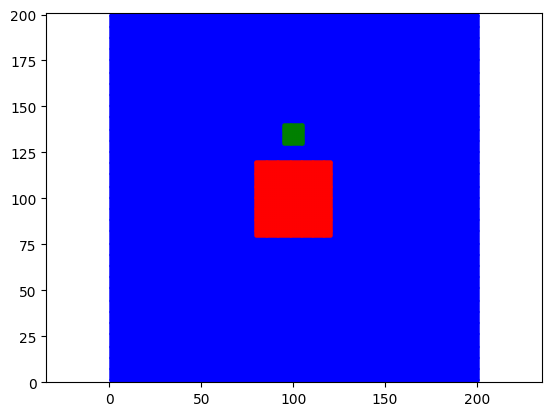

```
(0.0, 201.0)
```

```julia
function puntos_sistema(S,n_est,O,R)
    x=[]
    y=[]
    xo=[]
    yo=[]
    xR=[]
    yR=[]
    for s in S
        append!(x,s[1])
        append!(y,s[2])
        if n_est[s[1],s[2]] in O
            append!(xo,s[1])
            append!(yo,s[2])
        end
        if n_est[s[1],s[2]] in R
            append!(xR,s[1])
            append!(yR,s[2])
        end
    end
    return x,y,xo,yo,xR,yR
end
function pintar_sistema(x,y,xo,yo,xR,yR,plt)
    N=length(x)^0.5+1
    plt.scatter(x,y,s=5,c="blue")
    plt.scatter(xo,yo,s=5,c="green")
    plt.scatter(xR,yR,s=5,c="red")
    plt.axis("equal")
    plt.set_xlim((0,N))
    plt.set_ylim((0,N))
end
x,y,xo,yo,xR,yR=puntos_sistema(S,n_est,O,R)
pintar_sistema(x,y,xo,yo,xR,yR,gca())
```

## Iteración por política

Vamos a programar primero el algoritmo de iteración por política. Para ello, es necesario poder construir las matrices de transición dada una política. Por la formulación de este problema, esta matriz tendrá ceros en la mayoria de sus componentes, por lo que se puede guardar eficientemente en memoria en un formato sparse (CSC es el default en Julia). También será necesarió construir un vector de recompensas esperadas para cada estado.

```julia
function contruirP(S,acciones,estados_alcanzables,probabilidades_alcanzables,conjuntoProbs,pol)
    N=size(S)[1]
    P = SparseMatrixDict(N,N)
    for i in 1:N
        ind=indexin( pol[i], acciones[i] )[1]
        for (indj,j) in enumerate(estados_alcanzables[i][ind])
            P[i,j]=conjuntoProbs[probabilidades_alcanzables[i][ind]][indj]
        end
    end
    return sparse(P)
end

function contruir_r(S,R,O,pol)
    N=size(S)[1]
    r=Vector{Float64}(undef,N)
    for i in 1:N
        #ind=indexin( pol[i], acciones[i] )[1]
        r[i]=recom(i,R,O)
    end
    return r
end
```

```
contruir_r (generic function with 1 method)
```

Para inicializar el algoritmo será necesaria una política elegida de forma aleatoria, la cual construimos de la siguiente manera

```julia
pol0=Char[]
for a in acciones
    append!(pol0,a[rand(1:length(a))])
end
```

Para ilustrar la estructura general de las matrices de transición, calculemosla para esta política

```julia
P0=contruirP(S,acciones,es_al,prob_al,probs,pol0)
```

```
40000×40000 SparseMatrixCSC{Float64, Int64} with 158163 stored entries:
⠻⣦⡀⠀⠀⠀⠀⠀⠀⠀⠀⠀⠀⠀⠀⠀⠀⠀⠀⠀⠀⠀⠀⠀⠀⠀⠀⠀⠀⠀⠀⠀⠀⠀⠀⠀⠀⠀⠀⠀
⠀⠈⠻⣦⡀⠀⠀⠀⠀⠀⠀⠀⠀⠀⠀⠀⠀⠀⠀⠀⠀⠀⠀⠀⠀⠀⠀⠀⠀⠀⠀⠀⠀⠀⠀⠀⠀⠀⠀⠀
⠀⠀⠀⠈⠻⣦⡀⠀⠀⠀⠀⠀⠀⠀⠀⠀⠀⠀⠀⠀⠀⠀⠀⠀⠀⠀⠀⠀⠀⠀⠀⠀⠀⠀⠀⠀⠀⠀⠀⠀
⠀⠀⠀⠀⠀⠈⠻⣦⡀⠀⠀⠀⠀⠀⠀⠀⠀⠀⠀⠀⠀⠀⠀⠀⠀⠀⠀⠀⠀⠀⠀⠀⠀⠀⠀⠀⠀⠀⠀⠀
⠀⠀⠀⠀⠀⠀⠀⠈⠻⣦⡀⠀⠀⠀⠀⠀⠀⠀⠀⠀⠀⠀⠀⠀⠀⠀⠀⠀⠀⠀⠀⠀⠀⠀⠀⠀⠀⠀⠀⠀
⠀⠀⠀⠀⠀⠀⠀⠀⠀⠈⠻⣦⡀⠀⠀⠀⠀⠀⠀⠀⠀⠀⠀⠀⠀⠀⠀⠀⠀⠀⠀⠀⠀⠀⠀⠀⠀⠀⠀⠀
⠀⠀⠀⠀⠀⠀⠀⠀⠀⠀⠀⠈⠻⣦⡀⠀⠀⠀⠀⠀⠀⠀⠀⠀⠀⠀⠀⠀⠀⠀⠀⠀⠀⠀⠀⠀⠀⠀⠀⠀
⠀⠀⠀⠀⠀⠀⠀⠀⠀⠀⠀⠀⠀⠈⠻⣦⡀⠀⠀⠀⠀⠀⠀⠀⠀⠀⠀⠀⠀⠀⠀⠀⠀⠀⠀⠀⠀⠀⠀⠀
⠀⠀⠀⠀⠀⠀⠀⠀⠀⠀⠀⠀⠀⠀⠀⠈⠻⣦⡀⠀⠀⠀⠀⠀⠀⠀⠀⠀⠀⠀⠀⠀⠀⠀⠀⠀⠀⠀⠀⠀
⠀⠀⠀⠀⠀⠀⠀⠀⠀⠀⠀⠀⠀⠀⠀⠀⠀⠈⠻⣦⡀⠀⠀⠀⠀⠀⠀⠀⠀⠀⠀⠀⠀⠀⠀⠀⠀⠀⠀⠀
⠀⠀⠀⠀⠀⠀⠀⠀⠀⠀⠀⠀⠀⠀⠀⠀⠀⠀⠀⠈⠻⣦⡀⠀⠀⠀⠀⠀⠀⠀⠀⠀⠀⠀⠀⠀⠀⠀⠀⠀
⠀⠀⠀⠀⠀⠀⠀⠀⠀⠀⠀⠀⠀⠀⠀⠀⠀⠀⠀⠀⠀⠈⠻⣦⡀⠀⠀⠀⠀⠀⠀⠀⠀⠀⠀⠀⠀⠀⠀⠀
⠀⠀⠀⠀⠀⠀⠀⠀⠀⠀⠀⠀⠀⠀⠀⠀⠀⠀⠀⠀⠀⠀⠀⠈⠻⣦⡀⠀⠀⠀⠀⠀⠀⠀⠀⠀⠀⠀⠀⠀
⠀⠀⠀⠀⠀⠀⠀⠀⠀⠀⠀⠀⠀⠀⠀⠀⠀⠀⠀⠀⠀⠀⠀⠀⠀⠈⠻⣦⡀⠀⠀⠀⠀⠀⠀⠀⠀⠀⠀⠀
⠀⠀⠀⠀⠀⠀⠀⠀⠀⠀⠀⠀⠀⠀⠀⠀⠀⠀⠀⠀⠀⠀⠀⠀⠀⠀⠀⠈⠻⣦⡀⠀⠀⠀⠀⠀⠀⠀⠀⠀
⠀⠀⠀⠀⠀⠀⠀⠀⠀⠀⠀⠀⠀⠀⠀⠀⠀⠀⠀⠀⠀⠀⠀⠀⠀⠀⠀⠀⠀⠈⠻⣦⡀⠀⠀⠀⠀⠀⠀⠀
⠀⠀⠀⠀⠀⠀⠀⠀⠀⠀⠀⠀⠀⠀⠀⠀⠀⠀⠀⠀⠀⠀⠀⠀⠀⠀⠀⠀⠀⠀⠀⠈⠻⣦⡀⠀⠀⠀⠀⠀
⠀⠀⠀⠀⠀⠀⠀⠀⠀⠀⠀⠀⠀⠀⠀⠀⠀⠀⠀⠀⠀⠀⠀⠀⠀⠀⠀⠀⠀⠀⠀⠀⠀⠈⠻⣦⡀⠀⠀⠀
⠀⠀⠀⠀⠀⠀⠀⠀⠀⠀⠀⠀⠀⠀⠀⠀⠀⠀⠀⠀⠀⠀⠀⠀⠀⠀⠀⠀⠀⠀⠀⠀⠀⠀⠀⠈⠻⣦⡀⠀
⠀⠀⠀⠀⠀⠀⠀⠀⠀⠀⠀⠀⠀⠀⠀⠀⠀⠀⠀⠀⠀⠀⠀⠀⠀⠀⠀⠀⠀⠀⠀⠀⠀⠀⠀⠀⠀⠈⠻⣦
```

Ahora programemos la iteración por política siguiendo el algortimo propuesto en el libro. La única modificación que se realizó fue el criterio de actualización de políticas. Esto ya que para varios puntos en la malla la función de valor óptima esperada se alcanza para varias acciones posibles, pero a veces se distinguen ligeramente por el error de precisión numérico en el cálculo, por lo que para algunos estados la acción elegida no se estabiliza conforme se avanza el algoritmo, a pesar de que la función de valor calculada sí. Para evitar este error, una acción para un estado dado se actualiza solamente si la función de valor óptima calculada para este estado y esta acción difere en más de $10^{-3}$ de la función de valor óptima calculada en la iteración anterior. De esta manera el algoritmo sí converge con el criterio de parada establecido por el libro.

```julia
function iteracion_por_politica(pol0,λ,S,acciones,estados_alcanzables,probabilidades_alcanzables,conjuntoProbs,R,O)
    N=size(S)[1]
    p0=Vector{Char}(undef,N)
    p0=copy(pol0)
    p1=Vector{Char}(undef,N)
    v0=zeros(N)
    N_iter=0
    println("Comienza a calcular")
    while true
        Pn=contruirP(S,acciones,estados_alcanzables,probabilidades_alcanzables,conjuntoProbs,p0)
        M=sparse(I,N,N)-(λ*Pn)
        r=contruir_r(S,R,O,p0)
        rE=Pn*r
        vn=M\rE
        for i in 1:N
            pso=[]
            for (inda,a) in enumerate(acciones[i])
                suma=0
                cog=conjuntoProbs[probabilidades_alcanzables[i][inda]]
                for (inde,est) in enumerate(estados_alcanzables[i][inda])
                    suma+=cog[inde]*(λ*vn[est]+recom(est,R,O))
                end
                append!(pso,suma)
            end

            if (abs.(maximum(pso) .- pso).<1e-3)[indexin(p0[i],acciones[i])[1]]==true
                p1[i]=p0[i]
            else
                p1[i]=acciones[i][argmax(pso)]
            end
            if N_iter>70 && p1[i]!=p0[i]
                println(pso)
            end
        end
        N_iter+=1
        #println("Iteraciones: ",N_iter, " diferencias: ",sum(1 .- (p1.==p0)) ," Error en v: ",maximum(abs.(vn-v0)))
        if (p1==p0)
            println("Convergió en ",N_iter," iteraciones")
            return p1,p0
        end
        if (N_iter>100)
            return p1,p0
        end
        p0=copy(p1)
        v0=copy(vn)
    end

end
```

```
iteracion_por_politica (generic function with 1 method)
```

Calculemos entonces la política óptima para este problema usando $\lambda=0.99$. En total le toma al algoritmo 47 iteraciones para converger y un tiempo aproximado de 50 segundos de cálculo. Al final las políticas óptimas en la penúltima iteración y la última no difieren en ningún estado.

```julia
@time polopt,pan=iteracion_por_politica(pol0,0.99,S,acciones,es_al,prob_al,probs,R,O)
```

```
Comienza a calcular
Convergió en 47 iteraciones
 52.164302 seconds (504.54 M allocations: 15.565 GiB, 5.29% gc time, 4.16% compilation time)
```

```
(['u', 'r', 'r', 'r', 'r', 'r', 'r', 'r', 'r', 'r'  …  'l', 'd', 'd', 'l', 'l', 'l', 'l', 'l', 'l', 'l'], ['u', 'r', 'r', 'r', 'r', 'r', 'r', 'r', 'r', 'r'  …  'l', 'd', 'd', 'l', 'l', 'l', 'l', 'l', 'l', 'l'])
```

Podríamos intentar visualizar la política óptima hallada mediante un streamplot

```julia
function pintar_politica(S,pol,plt)
    N=Int(length(S)^0.5)
    x=zeros(N,N)
    y=zeros(N,N)
    u=zeros(N,N)
    v=zeros(N,N)
    for i in 1:length(S)
        y[S[i][1],S[i][2]]=S[i][1]
        x[S[i][1],S[i][2]]=S[i][2]
        if pol[i]=='u'
            u[S[i][1],S[i][2]]=1
        end
        if pol[i]=='d'
            u[S[i][1],S[i][2]]=-1
        end
        if pol[i]=='l'
            v[S[i][1],S[i][2]]=-1
        end
        if pol[i]=='r'
            v[S[i][1],S[i][2]]=1
        end
    end
    plt.streamplot(x,y,u,v,density=2,color="yellow")
end
```

```
pintar_politica (generic function with 1 method)
```

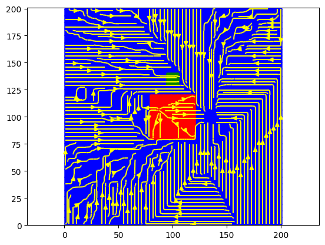

```
PyObject <matplotlib.streamplot.StreamplotSet object at 0x7feb325a4520>
```

```julia
pintar_sistema(x,y,xo,yo,xR,yR,gca())
pintar_politica(S, polopt,gca())
```

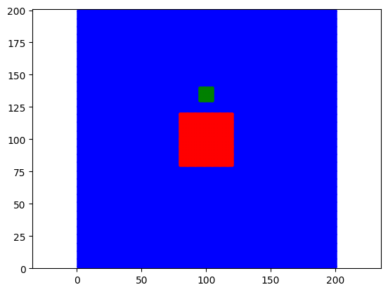

```
(0.0, 201.0)
```

```julia
function pintar_diferentes(sal,S,plt)
    xmal=[]
    ymal=[]
    dife=Array{Float64}(undef,length(S),length(S))
    for i in 1:length(S)
        if sal[i]==1
            append!(xmal,S[i][1])
            append!(ymal,S[i][2])
        end
    end
    plt.scatter(x,y,s=5,c="blue")
    plt.scatter(xo,yo,s=5,c="green")
    plt.scatter(xR,yR,s=5,c="red")
    plt.scatter(xmal,ymal,s=5,c="yellow")
    plt.axis("equal")
    plt.set_xlim((0,length(S)^0.5+1))
    plt.set_ylim((0,length(S)^0.5+1))
end
sal=1 .- (polopt.==pan)
pintar_diferentes(sal,S,gca())
```

```julia
function simular(s0,popt,S,acciones,estados_alcanzables,probabilidades_alcanzables,conjuntoProbs,plt,colorg="yellow")
    N=1
    xest=[s0[1]]
    yest=[s0[2]]
    while N<2*(length(S)^0.5)
        est=n_est[xest[end],yest[end]]
        pol=popt[est]
        indp=indexin(pol,acciones[est])[1]
        a_el=estados_alcanzables[est][indp]
        weights=conjuntoProbs[probabilidades_alcanzables[est][indp]]
        new= a_el[findfirst(cumsum(weights) .> rand())]
        append!(xest,S[new][1])
        append!(yest,S[new][2])
    N+=1
    end
    plt.plot(xest,yest,color=colorg)
    return xest,yest
end
```

```
simular (generic function with 2 methods)
```

Ahora simulemos trayectorias bajo esta política

Primero comenzemos las trayectorias en en el punto $(107,70)$

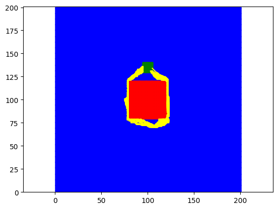

```julia
pintar_sistema(x,y,xo,yo,xR,yR,gca())
for i in 1:100
    xest,yest=simular([107,70],polopt,S,acciones,es_al,prob_al,probs,gca());
end
```

Ahora comenzemos las trayectorias en en el punto $(10,10)$

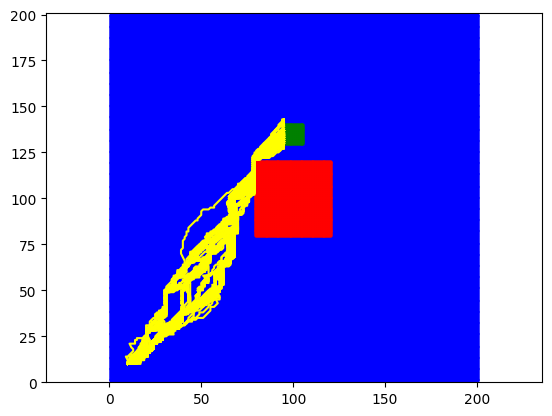

```julia
pintar_sistema(x,y,xo,yo,xR,yR,gca())
for i in 1:100
    xest,yest=simular([10,10],polopt,S,acciones,es_al,prob_al,probs,gca());
end
```

## Programación lineal

Ahora formulemos el problema como un problema de optimización lineal. Para esto vamos a usar JuMP, el lenguaje de modelación para problemas de optimación de Julia. Vamos también a usar el solver Tulip, que soporta usa métodos de punto interior con modificaciones que resuelven el problema dual simultaneamente.

```julia
using JuMP
using Tulip
```

Es más fácil introducir las restricciones del problema primal partiendo de la información del modelo que tenemos. Por lo tanto, formulamos el primal y el solver de Tulip halla simultaneamente la solución del primal y el dual, que es la que nos interesa para obtener las medidas de ocupación y con ellas construir las políticas óptimas.

```julia
function linear_programming_tulip(λ,κ,S,acciones,estados_alcanzables,probabilidades_alcanzables,conjuntoProbs,R,O)
    model = Model(Tulip.Optimizer)
    JuMP.set_optimizer_attribute(model, "IPM_IterationsLimit", 200)
    set_silent(model)
    N=length(S)
    total=0
    indices=[]
    @variable(model, v[1:N])
    @constraint(model,c[i=1:length(S),inda=1:length(acciones[i])],v[i]-sum(conjuntoProbs[probabilidades_alcanzables[i][inda]][indj]*(λ*v[j]+recom(j,R,O)) for (indj,j) in enumerate(estados_alcanzables[i][inda]))>=0)
    @objective(model, Min, κ'*v)
    #println(model)
    optimize!(model)
    medidas=[]
    for i in 1:length(S)
        mes=[]
        for j in 1:length(acciones[i])
            append!(mes,dual(c[i,j]))
        end
        append!(medidas,[mes])
    end
    return model,medidas
end
```

```
linear_programming_tulip (generic function with 1 method)
```

Como distribución inicial elegimos la distribución uniforme de tamaño $|S|$, es decir el vector de unos normalizado. Igual que en el caso anterior elegimos $\lambda=0.99$.

```julia
@time sol,medidas=linear_programming_tulip(0.99,ones(Float64,length(S))/length(S),S,acciones,es_al,prob_al,probs,R,O);
```

```
 43.312689 seconds (70.96 M allocations: 13.029 GiB, 5.81% gc time, 38.91% compilation time)
```

Como estamos usando un método de punto interior, las soluciones alcanzadas no necesariamente pertenecen a las esquinas del polítopo, por lo que no serían deterministas según la afirmación de Mauricio.

```julia
medidas[200:210]
```

```
11-element Vector{Any}:
 Any[2.0826075273945056e-9, 5.6479732079536124e-5]
 Any[9.168743067838076e-6, 2.4335451497212644e-10, 1.9740616540571273e-5]
 Any[1.704444554590049e-5, 2.0748312783309e-10, 2.2265584112185813e-10, 3.477321174716895e-5]
 Any[5.519299531008281e-10, 1.984174327098654e-10, 2.2057210327307972e-10, 9.579398015204526e-5]
 Any[5.490778729122108e-10, 1.9650764573908035e-10, 2.190062797436141e-10, 0.00010330346732465536]
 Any[5.451306032177679e-10, 1.922491589068634e-10, 2.174030510089904e-10, 9.177675057067317e-5]
 Any[5.415402250100435e-10, 1.8962353627170426e-10, 2.1589220220835972e-10, 9.28762514091097e-5]
 Any[5.380763751621255e-10, 1.87130940311168e-10, 2.1437119765083234e-10, 9.652334750095004e-5]
 Any[5.346356303612881e-10, 1.8476061729275442e-10, 2.1283367431608163e-10, 0.00010012548690666926]
 Any[5.312018250754406e-10, 1.8249479204357555e-10, 2.1127913488302683e-10, 0.00010381530638053163]
 Any[5.277549560769811e-10, 1.8031337884058613e-10, 2.0970878664788875e-10, 0.00010740251077729241]
```

```julia
function simular_aleatoria(s0,medidas,S,n_est,acciones,estados_alcanzables,probabilidades_alcanzables,conjuntoProbs,plt)
    N=1
    xest=[s0[1]]
    yest=[s0[2]]
    while N<2*(length(S)^0.5)
        est=n_est[xest[end],yest[end]]
        dis=medidas[est]
        dis=dis./sum(dis)
        indp=findfirst(cumsum(dis) .> rand())
        pol=acciones[est][indp]
        a_el=estados_alcanzables[est][indp]
        weights=conjuntoProbs[probabilidades_alcanzables[est][indp]]
        new= a_el[findfirst(cumsum(weights) .> rand())]
        append!(xest,S[new][1])
        append!(yest,S[new][2])
    N+=1
    end
    plt.plot(xest,yest,color="yellow")
    return xest,yest
end
```

```
simular_aleatoria (generic function with 1 method)
```

Sin embargo, el solver halla un óptimo que podemos usar para construir una política. Con esta podemos hacer simulaciones desde los mismos puntos iniciales que usamos antes

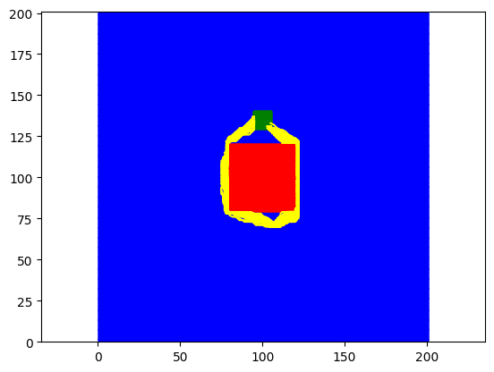

```julia
x,y,xo,yo,xR,yR=puntos_sistema(S,n_est,O,R)
pintar_sistema(x,y,xo,yo,xR,yR,gca())
for i in 1:100
    xest,yest=simular_aleatoria([107,70],medidas,S,n_est,acciones,es_al,prob_al,probs,gca());
end
```

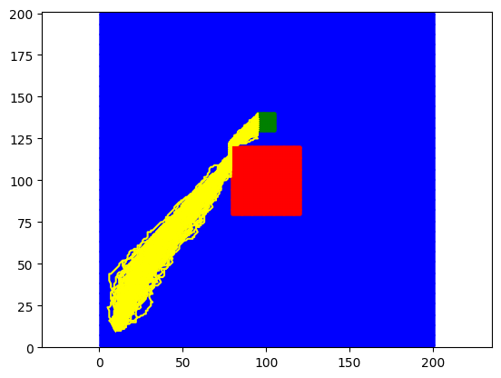

```julia
x,y,xo,yo,xR,yR=puntos_sistema(S,n_est,O,R)
pintar_sistema(x,y,xo,yo,xR,yR,gca())
for i in 1:100
    xest,yest=simular_aleatoria([10,10],medidas,S,n_est,acciones,es_al,prob_al,probs,gca());
end
```

Parece que la política aleatoria genera más disperción en los caminos del avión, pero el valor del tiempo esperado de llegar debe seguir siendo minimo.

También podríamos intentar usar un método tipo simplex para hallar una política determinista. Sin embargo para el problema con $N=200$ no encontré un solver gratuito lo pudiera resolver de este tamaño con método simplex. Por otro lado, el solver comercial de MOSEK tiene licencias academicas y si pudo

```julia
using Mosek;
using MosekTools;
function linear_programming_Mosek(λ,κ,S,acciones,estados_alcanzables,probabilidades_alcanzables,conjuntoProbs,R,O)
    model = Model(Mosek.Optimizer)

    set_optimizer_attribute(model, "MSK_DPAR_OPTIMIZER_MAX_TIME", 100.0)
    set_optimizer_attribute(model, "MSK_DPAR_BASIS_TOL_S", 1e-6)
    set_optimizer_attribute(model, "MSK_IPAR_OPTIMIZER", MSK_SOLVE_DUAL)
    #set_optimizer_attribute(model, "MSK_IPAR_OPTIMIZER", 0)
    set_silent(model)
    N=length(S)
    total=0
    indices=[]
    @variable(model, v[1:N])
    @constraint(model,c[i=1:length(S),inda=1:length(acciones[i])],v[i]-sum(conjuntoProbs[probabilidades_alcanzables[i][inda]][indj]*(λ*v[j]+recom(j,R,O)) for (indj,j) in enumerate(estados_alcanzables[i][inda]))>=0)
    @objective(model, Min, κ'*v)
    #println(model)
    optimize!(model)
    medidas=[]
    for i in 1:length(S)
        mes=[]
        for j in 1:length(acciones[i])
            append!(mes,dual(c[i,j]))
        end
        append!(medidas,[mes])
    end
    return model,medidas
end
```

```
linear_programming_Mosek (generic function with 1 method)
```

```julia
@time sol_sim,medidas_sim=linear_programming_Mosek(0.99,ones(Float64,length(S))/length(S),S,acciones,es_al,prob_al,probs,R,O);
```

```
 16.867874 seconds (25.96 M allocations: 1.225 GiB, 1.97% gc time, 16.95% compilation time)
```

Primero vemos que el solver comercial funciona muy rápido, se computa la solución en 15 segundos con el método simplex. Por otro lado, este no es el método más rápido del solver, el problema con métodos de punto interior se resuelve en apenas 6 segundos.

Tambien vemos que en el caso del solver simplex, las medidas de ocupación tienen casi toda la masa concentrada en solo una acción, lo que corresponde a una política determinista. El error puede ser debido a proximación numerica del solver.

```julia
medidas_sim[1:10]
```

```
10-element Vector{Any}:
 Any[2.499999918723579e-5, 1.208879389176781e-12]
 Any[7.530966116376917e-13, 1.9300537787302723e-13, 4.806977983573477e-5]
 Any[9.391583426175357e-13, 1.2438756738660415e-13, 5.8381950474497294e-5]
 Any[7.988674954085658e-13, 4.56021410411879e-13, 4.420048450458585e-5]
 Any[2.8537185480647197e-12, 1.2243731155018062e-13, 3.662823971385552e-5]
 Any[7.863462098195313e-13, 4.20697686527888e-12, 3.569351125915556e-5]
 Any[2.6043746660866083e-12, 1.2051770801672558e-13, 3.5578127049802676e-5]
 Any[7.768465074754354e-13, 3.733643678616148e-12, 3.5563883875802164e-5]
 Any[2.597953775224955e-12, 1.1862808277237566e-13, 3.556212565455e-5]
 Any[7.618896992225761e-13, 3.73169580506292e-12, 3.556190864578836e-5]
```

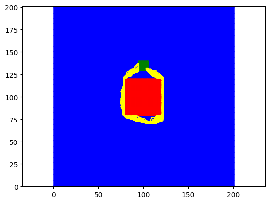

```julia
x,y,xo,yo,xR,yR=puntos_sistema(S,n_est,O,R)
pintar_sistema(x,y,xo,yo,xR,yR,gca())
for i in 1:100
    xest,yest=simular_aleatoria([107,70],medidas_sim,S,n_est,acciones,es_al,prob_al,probs,gca());
end
```

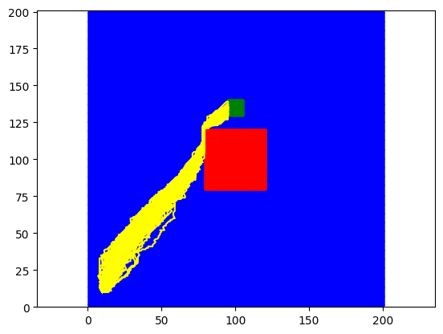

```julia
pintar_sistema(x,y,xo,yo,xR,yR,gca())
for i in 1:100
    xest,yest=simular_aleatoria([10,10],medidas_sim,S,n_est,acciones,es_al,prob_al,probs,gca());
end
```

Por otro lado, si cambiamos lo condición distribución inicial, por ejemplo para darle pesos aleatorios, parece que las políticas aleatorias halladas cambian, asignando diferentes pesos a las acciones. Pero se supone que deben tambien ser óptimas.

```julia
k0=rand(Float64,length(S))
@time sold,medidasd=linear_programming_Mosek(0.99,k0/sum(k0),S,acciones,es_al,prob_al,probs,R,O);
```

```
 13.331596 seconds (19.21 M allocations: 904.599 MiB, 2.83% gc time, 0.45% compilation time)
```

```julia
medidasd[200:210]
```

```
11-element Vector{Any}:
 Any[7.489686637341139e-15, 3.706841170405872e-5]
 Any[7.197307082116911e-6, 7.389659564998319e-16, 1.6694076989136755e-5]
 Any[2.4594276097100476e-5, 1.003534017968514e-15, 1.0114731554551809e-15, 4.320303266331598e-5]
 Any[2.0181413298157953e-15, 9.75345509968072e-16, 9.134948058728696e-16, 9.004163585628378e-5]
 Any[2.591821805334894e-15, 9.67668564296279e-16, 1.1416584246027774e-15, 9.400080380958783e-5]
 Any[2.5714137938380807e-15, 9.600525616012001e-16, 1.1317087508171595e-15, 8.293849064096716e-5]
 Any[2.5418341475677093e-15, 9.524968693389854e-16, 1.1237590000292878e-15, 9.22286878722924e-5]
 Any[2.5310963128367485e-15, 9.450001122029956e-16, 1.0346996038047376e-15, 7.890297681349131e-5]
 Any[2.5019863408670864e-15, 9.375627985818106e-16, 1.1061397013443812e-15, 9.36755321876013e-5]
 Any[2.4914159631394413e-15, 9.301840076653911e-16, 1.0170863503842141e-15, 0.0001063172828239264]
 Any[2.457508382794012e-15, 9.22863257024381e-16, 1.0888020592673055e-15, 0.00011705295038441769]
```

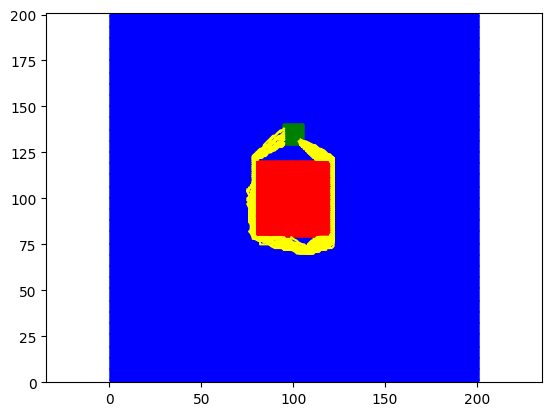

```julia
x,y,xo,yo,xR,yR=puntos_sistema(S,n_est,O,R)
pintar_sistema(x,y,xo,yo,xR,yR,gca())
for i in 1:100
    xest,yest=simular_aleatoria([107,70],medidasd,S,n_est,acciones,es_al,prob_al,probs,gca());
end
```

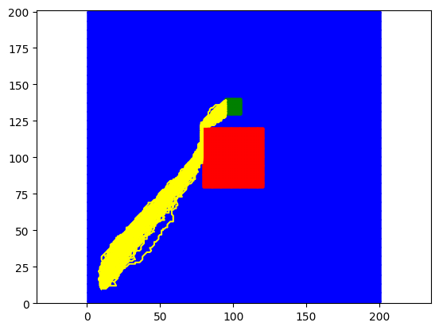

```julia
x,y,xo,yo,xR,yR=puntos_sistema(S,n_est,O,R)
pintar_sistema(x,y,xo,yo,xR,yR,gca())
for i in 1:100
    xest,yest=simular_aleatoria([10,10],medidasd,S,n_est,acciones,es_al,prob_al,probs,gca());
end
```

No se me ocurren criterios de comparación sistemáticos para comparar diferentes $k$, no sé que diferencias buscar si en la teoria no afectan demasiado.

## Sensibilidad a $\lambda$

Para evaluar la sensibilidad del problema al factor de descuento $\lambda$, calculemos políticas óptimas con $\lambda = 0.2,0.5,0.9,0.99,0.999$ con el método de iteración por política. Usamos este método ya que para el problema de $N=200$ converge suficientemente rápido y produce políticas deterministas que son más fáciles de comparar. Además el método de programación lineal me dió un poco de desconfianza porque en algunas pruebas, cuando se hacia $\lambda$ más cercano a 1, el problema se resolvía más rápido que con $\lambda$'s menores. Este comportamiento es inesperado, no lo sé explicar y prefiero evitar problemas.

```julia
pol0=Char[]
for a in acciones
    append!(pol0,a[rand(1:length(a))])
end

@time polopt02,pan=iteracion_por_politica(pol0,0.2,S,acciones,es_al,prob_al,probs,R,O)
@time polopt05,pan=iteracion_por_politica(pol0,0.5,S,acciones,es_al,prob_al,probs,R,O)
@time polopt09,pan=iteracion_por_politica(pol0,0.9,S,acciones,es_al,prob_al,probs,R,O)
@time polopt099,pan=iteracion_por_politica(pol0,0.99,S,acciones,es_al,prob_al,probs,R,O)
@time polopt0999,pan=iteracion_por_politica(pol0,0.999,S,acciones,es_al,prob_al,probs,R,O)
```

```
Comienza a calcular
Convergió en 6 iteraciones
  7.262853 seconds (64.05 M allocations: 2.040 GiB, 6.16% gc time, 3.09% compilation time: 98% of which was recompilation)
Comienza a calcular
Convergió en 7 iteraciones
  7.880840 seconds (74.00 M allocations: 2.342 GiB, 3.87% gc time)
Comienza a calcular
Convergió en 27 iteraciones
 30.110923 seconds (285.50 M allocations: 8.998 GiB, 3.68% gc time)
Comienza a calcular
Convergió en 50 iteraciones
 53.332157 seconds (529.14 M allocations: 16.185 GiB, 3.73% gc time)
Comienza a calcular
Convergió en 48 iteraciones
 51.224407 seconds (508.04 M allocations: 15.528 GiB, 3.77% gc time)
```

```
(['u', 'r', 'r', 'r', 'r', 'r', 'r', 'r', 'r', 'r'  …  'd', 'd', 'l', 'l', 'l', 'l', 'l', 'l', 'l', 'l'], ['u', 'r', 'r', 'r', 'r', 'r', 'r', 'r', 'r', 'r'  …  'd', 'd', 'l', 'l', 'l', 'l', 'l', 'l', 'l', 'l'])
```

Veamos la situación para el punto de inicio $(107,70)$

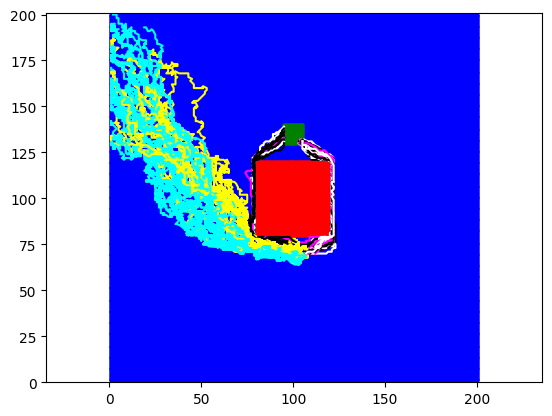

```julia
pintar_sistema(x,y,xo,yo,xR,yR,gca())
for i in 1:100
    xest,yest=simular([107,70],polopt02,S,acciones,es_al,prob_al,probs,gca());
    xest,yest=simular([107,70],polopt05,S,acciones,es_al,prob_al,probs,gca(),"cyan");
    xest,yest=simular([107,70],polopt09,S,acciones,es_al,prob_al,probs,gca(),"magenta");
    xest,yest=simular([107,70],polopt099,S,acciones,es_al,prob_al,probs,gca(),"black");
    xest,yest=simular([107,70],polopt0999,S,acciones,es_al,prob_al,probs,gca(),"white");
end
```

Vemos que conforme $\lambda \to 1$, las políticas intentan minimizar más el tiempo de llegada a la zona objetivo. Esto es lo esperado ya que el problema busca minimizar el costo esperado a largo plazo, que es cuando llega a la función objetivo. Si solo tenemos en cuenta recompensas esperadas en un tiempo cercano, entonces ni si quiera estamos intentado llegar a la zona objetivo, como sucede en los casos $\lambda =0.2,0.5$, que están representados por las trayectorias amarillas y cyan en la gráfica

Ahora veamos las trayectorias desde el punto de inicio $(10,10)$

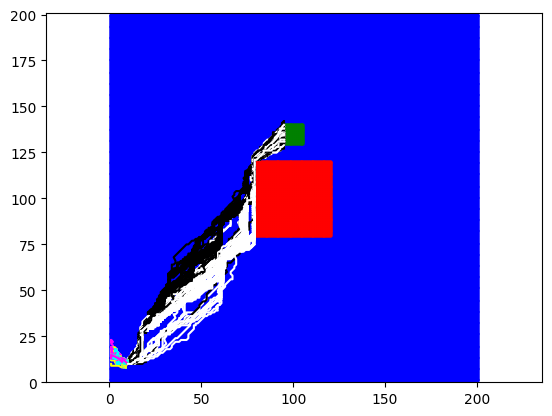

```julia
pintar_sistema(x,y,xo,yo,xR,yR,gca())
for i in 1:100
    xest,yest=simular([10,10],polopt02,S,acciones,es_al,prob_al,probs,gca());
    xest,yest=simular([10,10],polopt05,S,acciones,es_al,prob_al,probs,gca(),"cyan");
    xest,yest=simular([10,10],polopt09,S,acciones,es_al,prob_al,probs,gca(),"magenta");
    xest,yest=simular([10,10],polopt099,S,acciones,es_al,prob_al,probs,gca(),"black");
    xest,yest=simular([10,10],polopt0999,S,acciones,es_al,prob_al,probs,gca(),"white");
end
```

Vemos un caso parecido al anterior, pero como el punto inicial ahora está más lejos de la zona objetivo, ahora las trayectorias correspondientes a $\lambda=0.9$ ya no llegan a la zona objetivo. Esto tambien es esperable ya que se necesitan tener en cuenta más pasos en el futuro para asegurar la llegada a la zona objetivo, en donde las recompensas son las máximas posibles

## Conclusiones

- Ambos metodos funcionan eficientemente para hallar políticas óptimas. Si se modela un sistema con espacio de estados moderado y se dispone de un solver de programación lineal muy eficiente, este método puede ser más rápido que el método de iteración por política programado sin optimizar profesionalmente código. En este caso es mejor confiar en las grandes compañias productoras de software.
- El método de iteración por política parece no sufrir tanto con $\lambda$ más cerca a 1, a comparación del método de iteración por valor que se implementó en la tarea pasada, en donde el número de iteraciones escalaba considerablemente cuando se hacia $\lambda$ más cercano a 1.
- El método de programación lineal aparenta no ser suceptible a la escogencia de la distribución $\kappa$, como se espera en la teoría planteada. Sin embargo, habría que realizar más pruebas para ver si afecta en algo su escogencia en la práctica (tal vez algunas escogencias hagan el sistema lineal más fácil de resolver, por ejemplo, no sé).
- Para obtener caminos eficientes que minimizen el tiempo de llegada se requieren $\lambda$ suficientemente cercanos a 1.